# Regularización: Lasso, Ridge y Elastic Net

Juan Manuel Barriola y Diego Kozlowski

22-11-2018

```r
library(tidyverse)
library(broom)
library(ISLR)
library(GGally)
library(modelr)
library(cowplot)
library(glmnet)
library(rlang)
library(purrr)
library(caret)
set.seed(1992)
```

Las técnicas de **regularización** son útiles para trabajar con conjuntos con **gran cantidad de variables**, las cuales pueden introducir variabilidad en las estimaciones de los parámetros. El problema que vamos a tratar de resolver es **predecir** el **salario** de un **jugador de la NBA** en base a ciertos predictores.

# Conjuntos de datos

Vamos a utilizar dos conjuntos de datos provenientes de Kaggle:

Year: Season

Player: name

Pos: Position

Age: Age

Tm: Team

G: Games

GS: Games Started

MP: Minutes Played

PER: Player Efficiency Rating

TS%: True Shooting % : medida de eficiencia del jugador al lanzar

3PAr: 3-Point Attempt Rate

FTr:Free Throw Rate

ORB%: Offensive Rebound Percentage

DRB%: Defensive Rebound Percentage

TRB%: Total Rebound Percentage

AST%: Assist Percentage

STL%: Steal Percentage

BLK%: Block Percentage

TOV%: Turnover Percentage

USG%: Usage Percentage

OWS: Offensive Win Shares

DWS: Defensive Win Shares

WS: Win Shares

WS/48: Win Shares Per 48 Minutes

OBPM: Offensive Box Plus/Minus

DBPM: Defensive Box Plus/Minus

BPM: Box Plus/Minus : comparaciones contra el “jugador promedio” de la NBA

VORP: Value Over Replacement: Medida vinculada al BPM

FG: Field Goals

FGA: Field Goal Attempts

FG%: Field Goal Percentage

3P: 3-Point Field Goals

3PA: 3-Point Field Goal Attempts

3P%: 3-Point Field Goal Percentage

2P: 2-Point Field Goals

2PA: 2-Point Field Goal Attempts

2P%: 2-Point Field Goal Percentage

eFG%: Effective Field Goal Percentage

FT: Free Throws

FTA: Free Throw Attempts

FT%: Free Throw Percentage

ORB: Offensive Rebounds

DRB: Defensive Rebounds

TRB: Total Rebounds

AST: Assists

STL: Steals

BLK: Blocks

TOV: Turnovers

PF: Personal Fouls

PTS:Points

```r
# Los datos de salario son para la temporada 2017-2018
salarios <- read.csv("NBA_season1718_salary.csv", stringsAsFactors = F) %>% rename(salary=season17_18)
# Filtramos las estadisticas para quedarnos con la temporada 2017
estadisticas <- read.csv("Seasons_Stats.csv", stringsAsFactors = F) %>% filter(Year>= 2017) %>% select(-c(blanl, blank2))
head(salarios)
```

|  | X | Player | Tm | salary |
| --- | --- | --- | --- | --- |
| 1 | 1 | Stephen Curry | GSW | 34682550 |
| 2 | 2 | LeBron James | CLE | 33285709 |
| 3 | 3 | Paul Millsap | DEN | 31269231 |
| 4 | 4 | Gordon Hayward | BOS | 29727900 |
| 5 | 5 | Blake Griffin | DET | 29512900 |
| 6 | 6 | Kyle Lowry | TOR | 28703704 |

```r
colnames(estadisticas)
```

```
 [1] "X"      "Year"   "Player" "Pos"    "Age"    "Tm"     "G"      "GS"
 [9] "MP"     "PER"    "TS."    "X3PAr"  "FTr"    "ORB."   "DRB."   "TRB."
[17] "AST."   "STL."   "BLK."   "TOV."   "USG."   "OWS"    "DWS"    "WS"
[25] "WS.48"  "OBPM"   "DBPM"   "BPM"    "VORP"   "FG"     "FGA"    "FG."
[33] "X3P"    "X3PA"   "X3P."   "X2P"    "X2PA"   "X2P."   "eFG."   "FT"
[41] "FTA"    "FT."    "ORB"    "DRB"    "TRB"    "AST"    "STL"    "BLK"
[49] "TOV"    "PF"     "PTS"
```

Vemos que `salarios` contiene el nombre, equipo y salario en dolares de los jugadores.

`Estadisticas` es una tabla que contiene 51 variables, de las cuales 46 contienen información de muchas estadísticas de la temporada 2017-2018.

Hacemos el join por jugador y equipo. Un jugador puede ser cambiado/vendido durante la temporada. De esta manera mantenemos a los jugadores con las estadisticas correspondientes al equipo con quien acordaron el salario.

```r
# Join
nba <- inner_join(salarios, estadisticas, by=c('Player', 'Tm')) %>%
  select(-c(X.x, X.y, Year)) %>%
  drop_na() # Eliminamos los NA
```

# Analisis Exploratorio

### Gráfico de la relacion entre la posición y el salario

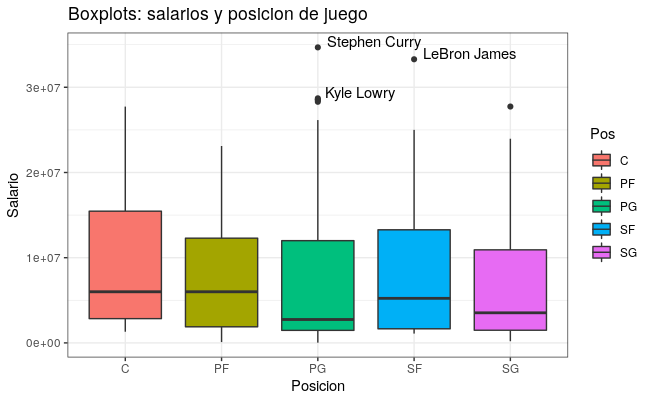

```r
ggplot(nba, aes(Pos, salary, fill=Pos)) +
  geom_boxplot() +
  geom_text(aes(label=ifelse(salary>28700000,as.character(Player),'')),hjust=-0.1,vjust=0) +
  theme_bw() +
  labs(title= "Boxplots: salarios y posicion de juego", x="Posicion", y="Salario")
```

Observamos que la distribución varía un poco entre posiciones y hay algunos jugaroes que son outliers.

### Correlagrama

Realizamos el correlograma entre todas las variables cuantitativas

```
data in column(s) 'Player', 'Tm', 'Pos' are not numeric and were ignored
```

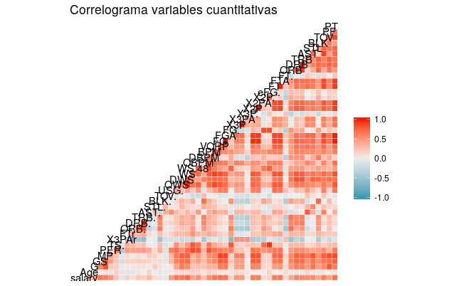

```r
ggcorr(nba, layout.exp = 2) + labs(title='Correlograma variables cuantitativas')
```

Observamos que existen relaciones de diversa magnitud y signo entre todas las variables

### GGpairs (algunas variables)

Seleccionamos algunas variables y vemos sus relaciones usando `ggpairs`.

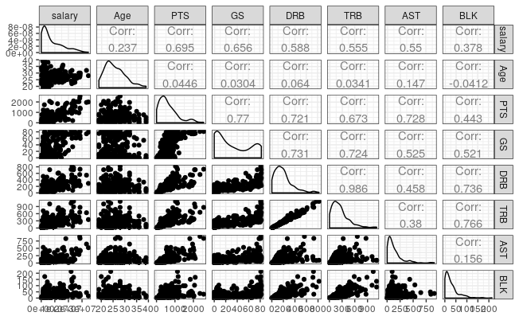

```r
nba %>% select(salary, Age, PTS, GS, DRB, TRB, AST, BLK) %>% ggpairs() + theme_bw()
```

Observamos que la correlación de todas estas variables con el **salario** es **positiva** pero de diversa magnitud.

También se ve que existen correlaciones muy fuertes entre ciertas variables. Por ejemplo entre **TRB** (Total de Rebotes) y **DRB** (Rebotes Defensivos)

# Modelo Lineal

Vamos a probar un modelo lineal que incluya todas las variables (excepto al jugador y equipo). Vamos a obtener las estimaciones de los parámetros junto a su p-valor e intervalo de confianza.

## Coeficientes estimados

Vemos los coeficientes estimados y sus p-valores asociados

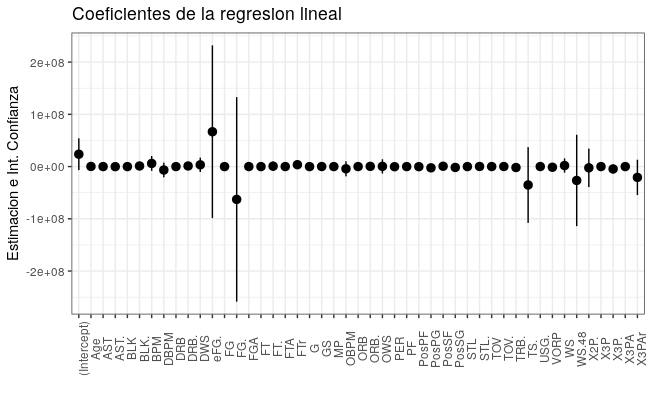

```r
# Eliminamos jugador y equipo
nba = nba %>% select(-c(Player, Tm))
# Modelo lineal
modelo_lineal = nba %>% lm(formula = salary~., data = .)
#Coeficientes
lineal_coef= modelo_lineal %>% tidy(conf.int=TRUE)

ggplot(lineal_coef, aes(term, estimate))+
  geom_point()+
  geom_pointrange(aes(ymin = conf.low, ymax = conf.high))+
  labs(title = "Coeficientes de la regresion lineal", x="", y="Estimacion e Int. Confianza") +
  theme_bw() +
  theme(axis.text.x = element_text(angle=90))
```

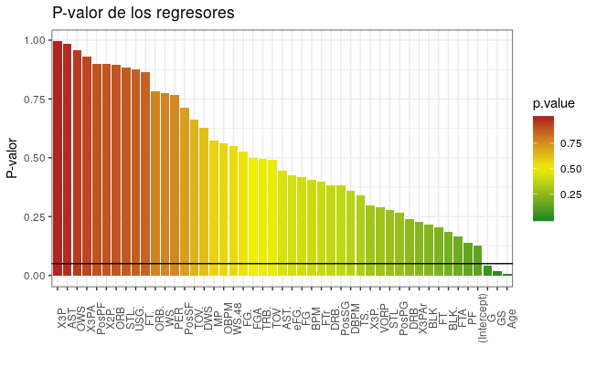

```r
ggplot(lineal_coef, aes(reorder(term, -p.value), p.value, fill=p.value))+
  geom_bar(stat = 'identity', aes(fill=p.value))+
  geom_hline(yintercept = 0.05) +
  labs(title = "P-valor de los regresores", x="", y="P-valor") +
  theme_bw() +
  theme(axis.text.x = element_text(angle=90)) +
  scale_fill_gradient2(high='firebrick', low = 'forestgreen', mid='yellow2',midpoint = 0.5 )
```

Notamos que

- Hay ciertas coeficientes estimados que presentan una gran variabilidad pero la escala de las variables puede ocultarnos la verdadera variabilidad de los estimadores
- Sólo tres variables tienen coeficientes significativos: **G**, **GS** y **Age**

Para evitar los problemas que puede introducir la escala, reescalamos las variables con el comando `scale`

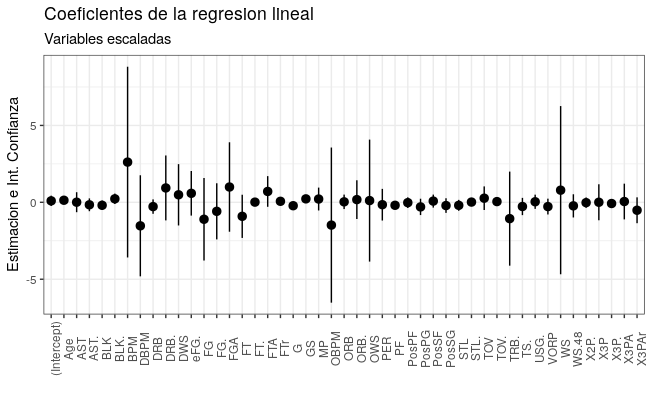

```r
# Reescalamos las variables numericas
nba_scaled = nba %>% mutate_at(vars(-Pos), scale)
# Nuevo modelo lineal
modelo_lineal_scal = nba_scaled %>% lm(formula = salary~., data = .)
lineal_coef_scal = modelo_lineal_scal %>% tidy(conf.int=TRUE)

ggplot(lineal_coef_scal, aes(term, estimate))+
  geom_point()+
  geom_pointrange(aes(ymin = conf.low, ymax = conf.high))+
  labs(title = "Coeficientes de la regresion lineal", subtitle="Variables escaladas", x="", y="Estimacion e Int. Confianza") +
  theme_bw() +
  theme(axis.text.x = element_text(angle=90))
```

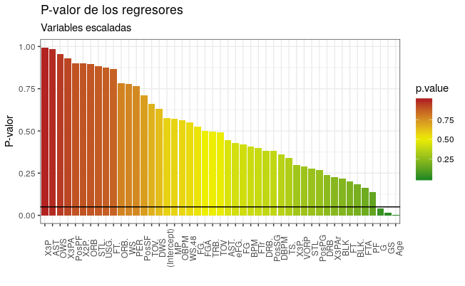

```r
ggplot(lineal_coef_scal, aes(reorder(term, -p.value), p.value, fill=p.value))+
  geom_bar(stat = 'identity', aes(fill=p.value))+
  geom_hline(yintercept = 0.05) +
  labs(title = "P-valor de los regresores",subtitle="Variables escaladas", x="", y="P-valor") +
  theme_bw() +
  theme(axis.text.x = element_text(angle=90)) +
  scale_fill_gradient2(high='firebrick', low = 'forestgreen', mid='yellow2',midpoint = 0.5 )
```

Ahora observamos que

- Los coeficientes cambian de valor
- Las mismas tres variables tienen coeficientes significativos: **G**, **GS** y **Age**

## Evaluacion de los modelos

Obtemos la evaluacion de ambos modelos ¿Cómo esperan que sean los valores de diagnóstico para ambos modelos?

```r
modelo_lineal = modelo_lineal %>% glance() %>% select(r.squared, adj.r.squared, p.value)
modelo_lineal_scal = modelo_lineal_scal %>% glance() %>% select(r.squared, adj.r.squared, p.value)
bind_rows(modelo_lineal, modelo_lineal_scal) %>% mutate(modelo= c('lineal', 'lineal_escalado'))
```

| r.squared | adj.r.squared | p.value | modelo |
| --- | --- | --- | --- |
| 0.693241 | 0.6240698 | 2.186855e-32 | lineal |
| 0.693241 | 0.6240698 | 2.186855e-32 | lineal_escalado |

La alta cantidad de variables y la existencia de una alta correlación entre varias de ellas ocasionas que los coeficientes estimados tengan alta varianza y que muchos de ellos no sean significativos en términos estadísticos. Las técnicas de **regularización** pueden ayudarnos a mejorar esta situación.

# Regularizacion

La libreria `glmnet` nos permite trabajar con modelos ridge, lasso y elastic net. La función que vamos a utilizar es `glmnet()`. Es necesario que le pasemos un objeto *matriz* con los regresores y un vector con la variable a explicar (en este caso los salarios)

Con el parámetro $\alpha$ indicamos con que tipo de modelo deseamos trabajar:

- Ridge: $\alpha=0$
- Lasso: $\alpha=1$
- Elastic Net: $0<\alpha<1$

### Partición Train y Testing

Realizamos una partición entre dataset de entrenamiento y testeo usando la función `resample_partition` del paquete **modelr**

```r
train_test <- nba %>% resample_partition(c(train=0.7,test=0.3))

nba <- train_test$train %>% as_tibble()
test <- train_test$test %>% as_tibble()
```

## Lasso

En este caso vamos a trabajar con $\alpha=1$.

1. ¿Cuál es la penalización que introduce el modelo Lasso?
2. ¿Cómo impacta esto en las variables?

```r
# Vector con los salarios
nba_salary = nba$salary
# Matriz con los regresores
nba_mtx = model.matrix(salary~., data = nba)

# Modelo Lasso
lasso.mod=glmnet(x=nba_mtx, # Matriz de regresores
                 y=nba_salary, #Vector de la variable a predecir
                 alpha=1, # Indicador del tipo de regularizacion
                 standardize = F) # Que esta haciendo este parametro?

lasso_coef = lasso.mod %>% tidy()

lasso_coef
```

| term | step | estimate | lambda | dev.ratio |
| --- | --- | --- | --- | --- |
| (Intercept) | 1 | 7.768149e+06 | 4070289420.3 | 0.00000000 |
| (Intercept) | 2 | 7.042496e+06 | 3708696126.7 | 0.06883011 |
| MP | 2 | 5.183072e+02 | 3708696126.7 | 0.06883011 |
| (Intercept) | 3 | 6.381307e+06 | 3379225784.7 | 0.12597408 |
| MP | 3 | 9.905694e+02 | 3379225784.7 | 0.12597408 |
| (Intercept) | 4 | 5.778856e+06 | 3079024679.8 | 0.17341600 |
| MP | 4 | 1.420877e+03 | 3079024679.8 | 0.17341600 |
| (Intercept) | 5 | 5.229926e+06 | 2805492613.7 | 0.21280312 |
| MP | 5 | 1.812958e+03 | 2805492613.7 | 0.21280312 |
| (Intercept) | 6 | 4.729761e+06 | 2556260382.3 | 0.24550300 |

[output cut: 814 more lines]

### Gráficos de analisis

El comando `plot` nos permite realizar dos graficos relevantes.

**Grafico de coeficientes en funcion del lambda**

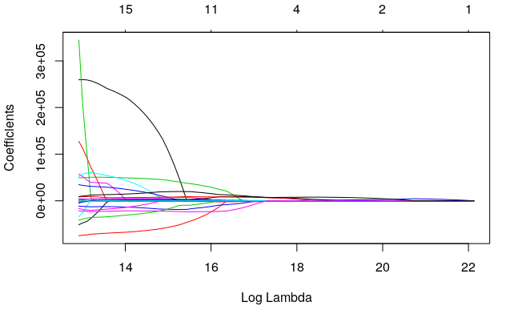

```r
plot(lasso.mod, 'lambda')
```

**Grafico de coeficientes en funcion de la norma de penalizacion**

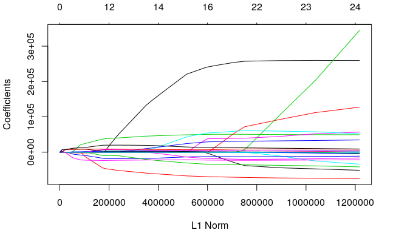

```r
plot(lasso.mod)
```

¿Qué muestra cada uno de estos graficos?

Podemos realizar los graficos para los valores de lambda en ggplot.

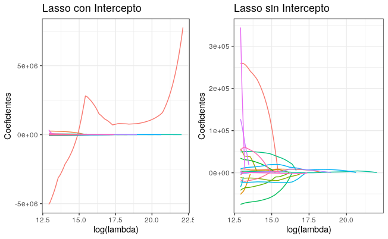

```r
g1=lasso_coef  %>% ggplot(., aes(log(lambda), estimate, group=term, color=term)) + geom_line() + theme_bw()  + theme(legend.position = 'none') +
  labs(title="Lasso con Intercepto",  y="Coeficientes")

g2=lasso_coef %>% filter(term!='(Intercept)') %>%
  ggplot(., aes(log(lambda), estimate, group=term, color=term)) + geom_line() + theme_bw()  + theme(legend.position = 'none') +
  labs(title="Lasso sin Intercepto", y="Coeficientes")

plot_grid(g1,g2)
```

Veamos un poco mejor aquellas variables que sobreviven para mayores valores de lambda ¿Qué tienen en común todas estas variables?

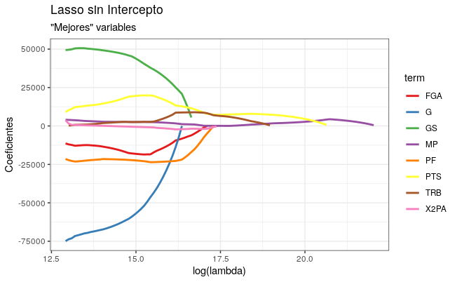

```r
lasso_coef %>% filter(term %in% c("G", "GS", "MP", "FGA", "X2PA", "TRB", "PF", "PTS")) %>%
  ggplot(., aes(log(lambda), estimate, group=term, color=term)) + geom_line(size=1) + theme_bw() +
  labs(title="Lasso sin Intercepto", y="Coeficientes", subtitle= "\"Mejores\" variables") +
  scale_color_brewer(palette = 'Set1')
```

Vemos que las variables que “sobreviven” para mayores valores de lambda son las que están medidas con una escala mayor.

## Estandarizacion en `glmnet`

Existen dos maneras de poder estandarizar las variables en `glmnet`.

1. Setear `standardize = TRUE`. Con esto se estandariza las regresoras, los coeficientes estimados estan en la escala original de la variable
2. Pasar los conjuntos de datos estandarizados.

## Lasso estandarizado

```r
# Modelo lasso
lasso.mod=glmnet(x=nba_mtx, # Matriz de regresores
                 y=nba_salary, #Vector de la variable a predecir
                 alpha=1, # Indicador del tipo de regularizacion
                 standardize = TRUE) # Estandarizamos

lasso_coef = lasso.mod %>% tidy()

lasso_coef
```

| term | step | estimate | lambda | dev.ratio |
| --- | --- | --- | --- | --- |
| (Intercept) | 1 | 7.768149e+06 | 5467652.80 | 0.00000000 |
| (Intercept) | 2 | 7.289156e+06 | 4981921.60 | 0.08664886 |
| WS | 2 | 1.538336e+05 | 4981921.60 | 0.08664886 |
| (Intercept) | 3 | 6.852714e+06 | 4539341.41 | 0.15858627 |
| WS | 3 | 2.940011e+05 | 4539341.41 | 0.15858627 |
| (Intercept) | 4 | 6.436685e+06 | 4136078.83 | 0.21936351 |
| WS | 4 | 4.111153e+05 | 4136078.83 | 0.21936351 |
| PTS | 4 | 8.224440e+01 | 4136078.83 | 0.21936351 |
| (Intercept) | 5 | 5.989513e+06 | 3768640.99 | 0.27317920 |
| WS | 5 | 4.744601e+05 | 3768640.99 | 0.27317920 |

[output cut: 990 more lines]

### Gráficos de analisis

El comando `plot` nos permite realizar dos graficos relevantes.

**Grafico de coeficientes en funcion del lambda**

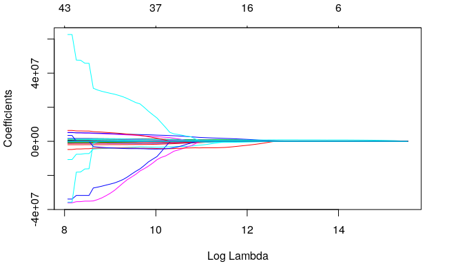

```r
plot(lasso.mod, 'lambda')
```

**Grafico de coeficientes en funcion de la norma de penalizacion**

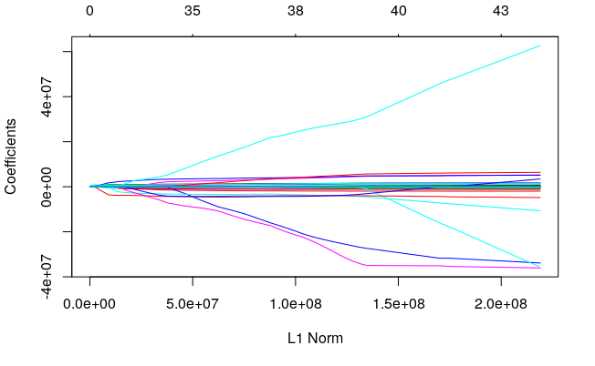

```r
plot(lasso.mod)
```

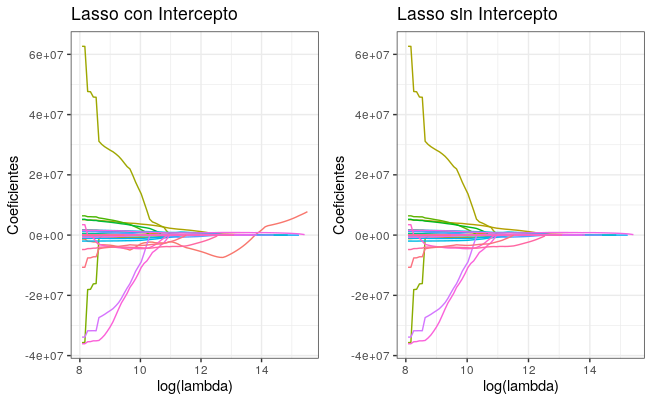

```r
g1=lasso_coef  %>% ggplot(., aes(log(lambda), estimate, group=term, color=term)) + geom_line() + theme_bw()  + theme(legend.position = 'none') +
  labs(title="Lasso con Intercepto",  y="Coeficientes")

g2=lasso_coef %>% filter(term!='(Intercept)') %>%
  ggplot(., aes(log(lambda), estimate, group=term, color=term)) + geom_line() + theme_bw()  + theme(legend.position = 'none') +
  labs(title="Lasso sin Intercepto", y="Coeficientes")

plot_grid(g1,g2)
```

¿Podemos decidir cuál es el valor óptimo de lambda?

### Elección lambda óptimo

Para elegir el valor óptimo de lambda, lo común es realizar cross-validation. La función `cv.glmnet` nos permite realizar esto de manera sencilla.

Al igual que para la función `glmnet` cuenta con los parámetros:

- **x**: matriz de variables
- **y**: vector de la variable a predecir
- **alpha**: tipo de modelo
- **standardize**: flag logico para estandarizar las variables

Nuevo parametro

- **type.measure**: funcion de perdida/error que se va a utilizar en CV. Para los modelos de regularizacion el default es MSE

**Salida Base**

```r
lasso_cv=cv.glmnet(x=nba_mtx,y=nba_salary,alpha=1, standardize = T)
lasso_cv
```

```
Call:  cv.glmnet(x = nba_mtx, y = nba_salary, alpha = 1, standardize = T)

Measure: Mean-Squared Error

     Lambda   Measure        SE Nonzero
min  486739 2.792e+13 3.050e+12       9
1se 1486430 3.094e+13 2.283e+12       4
```

Brinda muchisima informacion:

- lambda
- cvm (Cross-validation mean): es la media del MSE (error)
- cvsd (Cross-validation Standard Error): desvio estandar del MSE (error)
- cvup y cvlo: Limite superior e inferior
- nzero: Coeficientes distintos de cero
- lambda.min: lambda para el cual el MSE (error) es minimo
- lambda.1se: lambda que se encuentra a 1 desvío estandar de lambda.min

En glm.fit tenemos la cantidad de variables, el valor de lambda y el porcentaje de deviance explicada por el modelo

**Grafico Base**

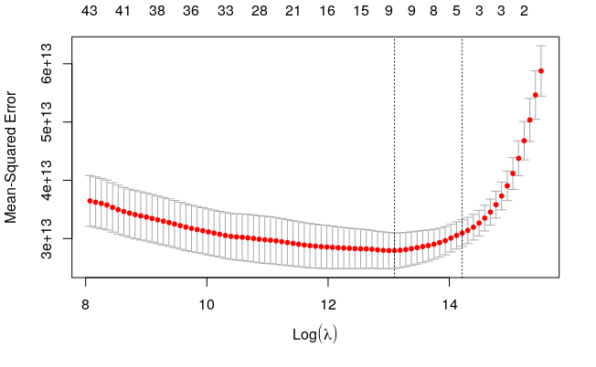

```r
plot(lasso_cv)
```

El gráfico nos muestra la media del MSE con su limite superior e inferior y la cantidad de varaibles que sobreviven para cada valor de lambda.

**Modelr**

Obtenemos la información del objeto **lasso_cv** con las funciones `tidy` y `glance`

```r
# Información de CV en dataframe con tidy
lasso_cv %>% tidy()
```

| lambda | estimate | std.error | conf.low | conf.high | nzero |
| --- | --- | --- | --- | --- | --- |
| 5467652.801 | 5.876692e+13 | 4.328371e+12 | 5.443855e+13 | 6.309530e+13 | 0 |
| 4981921.596 | 5.463944e+13 | 4.148323e+12 | 5.049112e+13 | 5.878777e+13 | 1 |
| 4539341.412 | 5.035238e+13 | 3.687056e+12 | 4.666532e+13 | 5.403943e+13 | 1 |
| 4136078.833 | 4.679071e+13 | 3.297370e+12 | 4.349334e+13 | 5.008808e+13 | 2 |
| 3768640.989 | 4.376560e+13 | 2.977478e+12 | 4.078812e+13 | 4.674308e+13 | 2 |
| 3433845.311 | 4.116693e+13 | 2.724426e+12 | 3.844251e+13 | 4.389136e+13 | 2 |
| 3128791.958 | 3.904619e+13 | 2.526462e+12 | 3.651973e+13 | 4.157265e+13 | 2 |
| 2850838.704 | 3.730868e+13 | 2.381992e+12 | 3.492669e+13 | 3.969067e+13 | 3 |
| 2597578.051 | 3.581542e+13 | 2.286390e+12 | 3.352903e+13 | 3.810181e+13 | 3 |
| 2366816.376 | 3.454454e+13 | 2.235300e+12 | 3.230924e+13 | 3.677984e+13 | 3 |

[output cut: 71 more lines]

```r
# Lambda minimo y lambda a 1 desvio estandar
lasso_cv %>% glance()
```

| lambda.min | lambda.1se |
| --- | --- |
| 486738.7 | 1486430 |

Seleccionamos el lambda optimo para crear el modelo final

```r
# Selección lambda óptimo
lasso_lambda_opt = lasso_cv$lambda.min

# Entrenamiento modelo óptimo
lasso_opt = glmnet(x=nba_mtx, # Matriz de regresores
                 y=nba_salary, #Vector de la variable a predecir
                 alpha=1, # Indicador del tipo de regularizacion
                 standardize = TRUE,  # Estandarizamos
                 lambda = lasso_lambda_opt)

# Salida estandar
lasso_opt
```

```
Call:  glmnet(x = nba_mtx, y = nba_salary, alpha = 1, lambda = lasso_lambda_opt,      standardize = TRUE)

  Df   %Dev Lambda
1  9 0.5878 486700
```

```r
# Tidy
lasso_opt %>% tidy()
```

| term | step | estimate | lambda | dev.ratio |
| --- | --- | --- | --- | --- |
| (Intercept) | 1 | -5643759.4870 | 486738.7 | 0.5878247 |
| Age | 1 | 209078.3847 | 486738.7 | 0.5878247 |
| GS | 1 | 51617.1725 | 486738.7 | 0.5878247 |
| USG. | 1 | 129881.5270 | 486738.7 | 0.5878247 |
| DWS | 1 | 156683.7338 | 486738.7 | 0.5878247 |
| WS | 1 | 863963.1380 | 486738.7 | 0.5878247 |
| X3P | 1 | 435.3404 | 486738.7 | 0.5878247 |
| AST | 1 | 2498.2263 | 486738.7 | 0.5878247 |
| TOV | 1 | 1786.6605 | 486738.7 | 0.5878247 |
| PTS | 1 | 837.0432 | 486738.7 | 0.5878247 |

```r
# Glance (no es muy informativo)
lasso_opt %>% glance()
```

| nulldev | npasses |
| --- | --- |
| 1.025108e+16 | 180 |

```r
NA
```

## Ridge

En este caso vamos a trabajar con $\alpha=0$. Vamos a replicar lo que ya realizamos para Lasso.

1. ¿Cuál es la penalización que introduce el modelo Ridge?
2. ¿Cómo impacta esto en las variables?

```r
#Modelo ridge
ridge.mod=glmnet(x=nba_mtx, # Matriz de regresores
                 y=nba_salary, #Vector de la variable a predecir
                 alpha=0, # Indicador del tipo de regularizacion
                 standardize = TRUE)
#Coeficientes tidy
ridge_coef= ridge.mod %>% tidy()

ridge_coef
```

| term | step | estimate | lambda | dev.ratio |
| --- | --- | --- | --- | --- |
| (Intercept) | 1 | 7.768149e+06 | 5467652801 | 2.004693e-35 |
| PosPF | 1 | 1.255590e-31 | 5467652801 | 2.004693e-35 |
| PosPG | 1 | -1.424200e-30 | 5467652801 | 2.004693e-35 |
| PosSF | 1 | 3.571785e-31 | 5467652801 | 2.004693e-35 |
| PosSG | 1 | -7.068106e-31 | 5467652801 | 2.004693e-35 |
| Age | 1 | 3.995324e-31 | 5467652801 | 2.004693e-35 |
| G | 1 | 1.283207e-31 | 5467652801 | 2.004693e-35 |
| GS | 1 | 1.650703e-31 | 5467652801 | 2.004693e-35 |
| MP | 1 | 5.893279e-33 | 5467652801 | 2.004693e-35 |
| PER | 1 | 7.046387e-31 | 5467652801 | 2.004693e-35 |

[output cut: 990 more lines]

¿Qué ven de distinto en los coeficientes estimados del modelo respecto a Lasso?

### Gráficos de analisis

**Grafico de coeficientes en funcion del lambda**

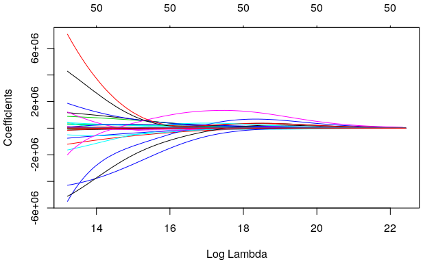

```r
plot(ridge.mod, 'lambda')
```

¿Qué ven de distinto en este gráfico respecto al que obtuvimos con la regresión Lasso?

**Grafico de coeficientes en funcion de la norma de penalizacion**

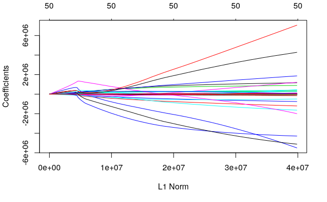

```r
plot(ridge.mod)
```

#### Gráficos de analisis GGplot

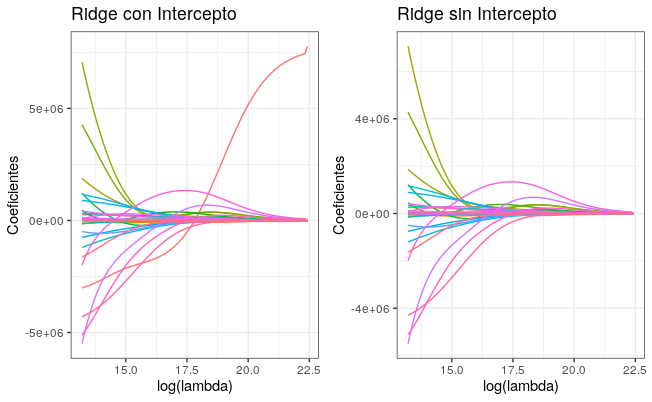

```r
g1=ridge_coef  %>% ggplot(., aes(log(lambda), estimate, group=term, color=term)) + geom_line() + theme_bw()  + theme(legend.position = 'none') +
  labs(title="Ridge con Intercepto",  y="Coeficientes")

g2=ridge_coef %>% filter(term!='(Intercept)') %>%
  ggplot(., aes(log(lambda), estimate, group=term, color=term)) + geom_line() + theme_bw()  + theme(legend.position = 'none') +
  labs(title="Ridge sin Intercepto", y="Coeficientes")

plot_grid(g1,g2)
```

### Elección lambda óptimo

```r
ridge_cv=cv.glmnet(x=nba_mtx,y=nba_salary,alpha=0, standardize = T)
```

**Grafico Base**

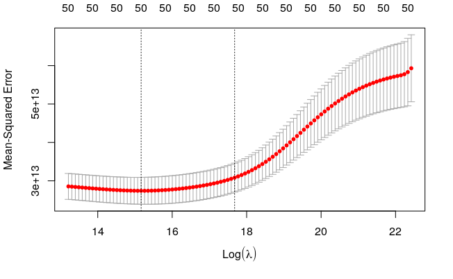

```r
plot(ridge_cv)
```

Seleccionamos el lambda óptimo para crear el modelo final

```r
# Selección lambda óptimo
ridge_lambda_opt = ridge_cv$lambda.min

# Entrenamiento modelo óptimo
ridge_opt = glmnet(x=nba_mtx, # Matriz de regresores
                 y=nba_salary, #Vector de la variable a predecir
                 alpha=0, # Indicador del tipo de regularizacion
                 standardize = TRUE,  # Estandarizamos
                 lambda = ridge_lambda_opt)

# Salida estandar
ridge_opt
```

```
Call:  glmnet(x = nba_mtx, y = nba_salary, alpha = 0, lambda = ridge_lambda_opt,      standardize = TRUE)

  Df   %Dev  Lambda
1 50 0.6096 3857000
```

```r
# Tidy
ridge_opt %>% tidy()
```

| term | step | estimate | lambda | dev.ratio |
| --- | --- | --- | --- | --- |
| (Intercept) | 1 | -2025593.0827 | 3857321 | 0.6095611 |
| PosPF | 1 | 627201.8772 | 3857321 | 0.6095611 |
| PosPG | 1 | -525853.3170 | 3857321 | 0.6095611 |
| PosSF | 1 | 575833.1867 | 3857321 | 0.6095611 |
| PosSG | 1 | -337577.9316 | 3857321 | 0.6095611 |
| Age | 1 | 199880.6317 | 3857321 | 0.6095611 |
| G | 1 | -23693.7630 | 3857321 | 0.6095611 |
| GS | 1 | 27262.0583 | 3857321 | 0.6095611 |
| MP | 1 | 370.6189 | 3857321 | 0.6095611 |
| PER | 1 | 14143.7303 | 3857321 | 0.6095611 |

[output cut: 41 more lines]

## Elastic Net

El modelo Elastic Net incorpora los dos tipos de penalización: Lasso (Norma L1) y Ridge (Norma L2). El parámetro $\alpha$ regula la importancia de cada penalización, cuanto más cerca de cero será más importante la penalización del tipo Ridge y más cerca de 1, la tipo Lasso.

En este caso vamos a trabajar con $\alpha=0.5$. Vamos a replicar lo que ya realizamos para Lasso y Ridge

```r
# Modelo elastic net
elastic.mod=glmnet(x=nba_mtx, # Matriz de regresores
                 y=nba_salary, #Vector de la variable a predecir
                 alpha=0.5, # Indicador del tipo de regularizacion
                 standardize = TRUE)

# Coeficientes del modelo
elastic_coef= elastic.mod %>% tidy()

elastic_coef
```

| term | step | estimate | lambda | dev.ratio |
| --- | --- | --- | --- | --- |
| (Intercept) | 1 | 7.768149e+06 | 10935305.60 | 0.00000000 |
| (Intercept) | 2 | 7.452539e+06 | 9963843.19 | 0.05619177 |
| WS | 2 | 8.773791e+04 | 9963843.19 | 0.05619177 |
| PTS | 2 | 6.791754e+01 | 9963843.19 | 0.05619177 |
| (Intercept) | 3 | 6.999687e+06 | 9078682.82 | 0.12184433 |
| WS | 3 | 1.411133e+05 | 9078682.82 | 0.12184433 |
| FG | 3 | 5.226743e+02 | 9078682.82 | 0.12184433 |
| PTS | 3 | 3.323396e+02 | 9078682.82 | 0.12184433 |
| (Intercept) | 4 | 6.569425e+06 | 8272157.67 | 0.18085382 |
| OWS | 4 | 1.416992e+04 | 8272157.67 | 0.18085382 |

[output cut: 990 more lines]

¿Qué ven de distinto en los coeficientes estimados del modelo respecto a Lasso y Ridge?

### Gráficos de analisis

**Grafico de coeficientes en funcion del lambda**

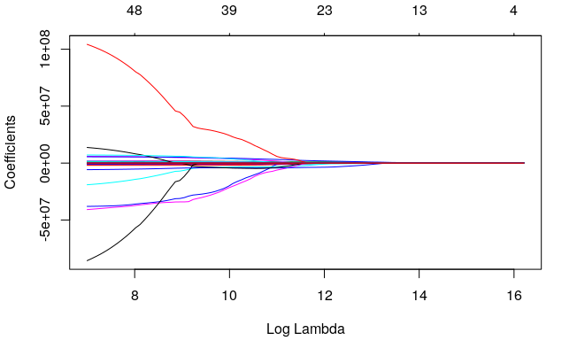

```r
plot(elastic.mod, 'lambda')
```

¿Qué ven en este gráfico de distinto a los dos anteriores?

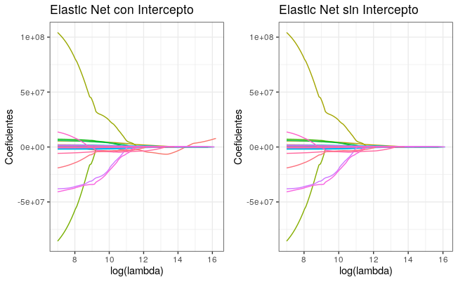

```r
g1=elastic_coef  %>% ggplot(., aes(log(lambda), estimate, group=term, color=term)) + geom_line() + theme_bw()  + theme(legend.position = 'none') +
  labs(title="Elastic Net con Intercepto",  y="Coeficientes")

g2=elastic_coef %>% filter(term!='(Intercept)') %>%
  ggplot(., aes(log(lambda), estimate, group=term, color=term)) + geom_line() + theme_bw()  + theme(legend.position = 'none') +
  labs(title="Elastic Net sin Intercepto", y="Coeficientes")

plot_grid(g1,g2)
```

### Elección lambda óptimo

```r
elastic_cv=cv.glmnet(x=nba_mtx,y=nba_salary,alpha=0.5, standardize = T)
```

**Grafico Base**

Presten especial atención al eje superior ¿Qué está sucediendo?

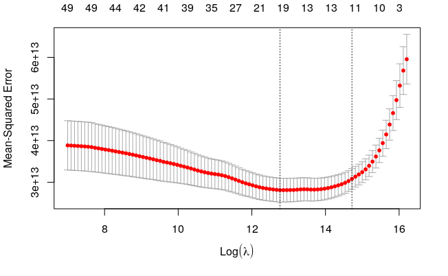

```r
plot(elastic_cv)
```

Seleccionamos el lambda optimo para crear el modelo final

```r
# Selección lambda óptimo
elastic_lambda_opt = elastic_cv$lambda.min

# Entrenamiento modelo óptimo
elastic_opt = glmnet(x=nba_mtx, # Matriz de regresores
                 y=nba_salary, #Vector de la variable a predecir
                 alpha=0.5, # Indicador del tipo de regularizacion
                 standardize = TRUE,  # Estandarizamos
                 lambda = elastic_lambda_opt)

# Salida estandar
elastic_opt
```

```
Call:  glmnet(x = nba_mtx, y = nba_salary, alpha = 0.5, lambda = elastic_lambda_opt,      standardize = TRUE)

  Df   %Dev Lambda
1 18 0.6237 349800
```

```r
# Tidy
elastic_opt %>% tidy()
```

| term | step | estimate | lambda | dev.ratio |
| --- | --- | --- | --- | --- |
| (Intercept) | 1 | -5624901.9555 | 349849.6 | 0.6237429 |
| PosPF | 1 | 610303.5281 | 349849.6 | 0.6237429 |
| PosSF | 1 | 679933.1680 | 349849.6 | 0.6237429 |
| Age | 1 | 263402.8706 | 349849.6 | 0.6237429 |
| G | 1 | -37383.4215 | 349849.6 | 0.6237429 |
| GS | 1 | 51647.6000 | 349849.6 | 0.6237429 |
| STL. | 1 | -338017.4676 | 349849.6 | 0.6237429 |
| BLK. | 1 | -41522.8624 | 349849.6 | 0.6237429 |
| USG. | 1 | 131735.7439 | 349849.6 | 0.6237429 |
| OWS | 1 | 200569.1801 | 349849.6 | 0.6237429 |

[output cut: 9 more lines]

## Breve comparacion entre modelos

Vamos a comparar la relación entre el porcentaje de deviance explicada y lambda para los tres tipos de modelos que realizamos

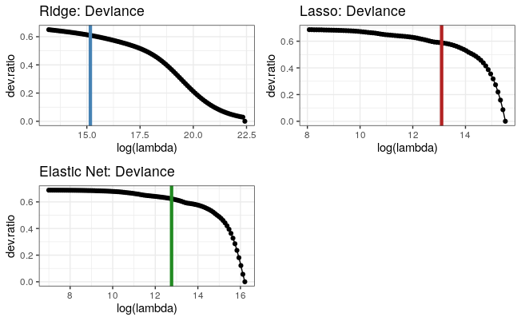

```r
ridge_dev = ridge_coef %>% select(lambda, dev.ratio) %>% distinct() %>%
  ggplot(., aes(log(lambda), dev.ratio)) +
  geom_point() +
  geom_line() +
  geom_vline(xintercept = log(ridge_lambda_opt), color='steelblue', size=1.5) +
  labs(title='Ridge: Deviance') +
  theme_bw()

lasso_dev = lasso_coef %>% select(lambda, dev.ratio) %>% distinct() %>%
  ggplot(., aes(log(lambda), dev.ratio)) +
  geom_point() +
  geom_line() +
  geom_vline(xintercept = log(lasso_lambda_opt), color='firebrick', size=1.5) +
  labs(title='Lasso: Deviance') +
  theme_bw()

elastic_dev = elastic_coef %>% select(lambda, dev.ratio) %>% distinct() %>%
  ggplot(., aes(log(lambda), dev.ratio)) +
  geom_point() +
  geom_line() +
  geom_vline(xintercept = log(elastic_lambda_opt), color='forestgreen', size=1.5) +
  labs(title='Elastic Net: Deviance') +
  theme_bw()

plot_grid(ridge_dev, lasso_dev, elastic_dev)
```

## Testing

Con los modelos optimos que encontramos pueden probar cual es el MSE y RMSE en los datasets de training y testing, para decidir cual es el modelo que minimiza el error en las predicciones.